# DDS_CaseStudy2

Daniel Clark

8/2/2019

# DDSAnalytics Attrition and Salary analysis for Frito Lay Employees

## Executive Summary

As businesses are more competitive than ever before, it is more important than ever before to be able to ensure top talent are available on a company roster helping your company get an edge. That’s why we reviewed over 1,100 employees at Frito-Lay as well as some survey and raise data to learn more about trends in the workplace.

To help predict attrition, we were able to run a random forest model to gain an 86% accuracy, while also learning that Overtime, Monthly Income and Job Role are the best predictors of attrition at Frito Lay.

For Salary, we were also able to build a random forest model with a fit that has an RMSE below $2,000 per monthly income. This shows us that the biggest predictors of Job Salary are Years in Current Role, Job Role, and Age. This will be very useful in helping to manage the employee population to reduce attrition and understanding the inputs that are driving an employees salary.

## Introduction

The modern workforce in the United States is becoming more fluid than ever before. As the cost of living in the country continues to increase, wages are remaining stagnant, as reported in the latest economic trends. A result of this, we are seeing more employees shift between companies after just a few years and using the larger pay raise associated with switching jobs (as compared to staying put a single job) as a way to bolster their income to make a living.

To combat this trend and potentially get a closer feel of the status of each employee and their potential for attribution, we are going to conduct a data analysis to identify trends in the employee base job titles, overall sentiment as well as salary with hopes to be able to predict which employee is likely to leave the company and what salaries are associated with the employee’s current standing.

# Primary Objectives

1.) Explore Interesting Trends within the Frito Lay employee base specific to attrition and job role 2.) Build a model that predicts attrition and monthly income 3.) Present the top 3 variables that are key components for predicting attrition and salary

### Loading our data

```r
knitr::opts_chunk$set(echo = TRUE)
```

```r
library(dplyr)
library(tidyverse)
```

```r
library(ggplot2)
library(stats)

employment <- "https://raw.githubusercontent.com/dclark18/MSDS_DanielClark_EmployementAttrition/master/CaseStudy2-data.csv"
traindata <- read.csv(url(employment))

attrition <- 'https://raw.githubusercontent.com/dclark18/MSDS_DanielClark_EmployementAttrition/master/CaseStudy2CompSet%20No%20Attrition.csv'
testattrition <- read.csv(url(attrition))

salary <- 'https://raw.githubusercontent.com/dclark18/MSDS_DanielClark_EmployementAttrition/master/CaseStudy2CompSet%20No%20Salary.csv'
testsalary <- read.csv(url(salary))

head(traindata)
```

```
##   ID Age Attrition    BusinessTravel DailyRate             Department
## 1  1  32        No     Travel_Rarely       117                  Sales
## 2  2  40        No     Travel_Rarely      1308 Research & Development
## 3  3  35        No Travel_Frequently       200 Research & Development
## 4  4  32        No     Travel_Rarely       801                  Sales
## 5  5  24        No Travel_Frequently       567 Research & Development
## 6  6  27        No Travel_Frequently       294 Research & Development
##   DistanceFromHome Education   EducationField EmployeeCount EmployeeNumber
## 1               13         4    Life Sciences             1            859
## 2               14         3          Medical             1           1128
## 3               18         2    Life Sciences             1           1412
## 4                1         4        Marketing             1           2016
## 5                2         1 Technical Degree             1           1646
## 6               10         2    Life Sciences             1            733
##   EnvironmentSatisfaction Gender HourlyRate JobInvolvement JobLevel
```

[output cut: 48 more lines]

```r
head(testattrition)
```

```
##     ID Age    BusinessTravel DailyRate             Department
## 1 1171  35     Travel_Rarely       750 Research & Development
## 2 1172  33     Travel_Rarely       147        Human Resources
## 3 1173  26     Travel_Rarely      1330 Research & Development
## 4 1174  55     Travel_Rarely      1311 Research & Development
## 5 1175  29     Travel_Rarely      1246                  Sales
## 6 1176  51 Travel_Frequently      1456 Research & Development
##   DistanceFromHome Education  EducationField EmployeeCount EmployeeNumber
## 1               28         3   Life Sciences             1           1596
## 2                2         3 Human Resources             1           1207
## 3               21         3         Medical             1           1107
## 4                2         3   Life Sciences             1            505
## 5               19         3   Life Sciences             1           1497
## 6                1         4         Medical             1            145
##   EnvironmentSatisfaction Gender HourlyRate JobInvolvement JobLevel
```

[output cut: 48 more lines]

```r
head(testsalary)
```

```
##    ID Age Attrition    BusinessTravel DailyRate             Department
## 1 871  43        No Travel_Frequently      1422                  Sales
## 2 872  33        No     Travel_Rarely       461 Research & Development
## 3 873  55       Yes     Travel_Rarely       267                  Sales
## 4 874  36        No        Non-Travel      1351 Research & Development
## 5 875  27        No     Travel_Rarely      1302 Research & Development
## 6 876  39       Yes     Travel_Rarely       895                  Sales
##   DistanceFromHome Education   EducationField EmployeeCount EmployeeNumber
## 1                2         4    Life Sciences             1           1849
## 2               13         1    Life Sciences             1            995
## 3               13         4        Marketing             1           1372
## 4                9         4    Life Sciences             1           1949
## 5               19         3            Other             1           1619
## 6                5         3 Technical Degree             1             42
##   EnvironmentSatisfaction Gender HourlyRate JobInvolvement JobLevel
```

[output cut: 41 more lines]

Frito Lay Supplied first-party data on over 1,100 employees as well as some detail on their Age, level of business travel, daily income rate, department, the distance they live from the office, education, gender, job role, performance rating and tenure at the company. We will be able to utilize this code to carry out our study to predict attribution and salary.

# Data Overview and Cleaning

```r
# ID the structure of our dataset to see if there is any misidentified data
# str(traindata)
# str(testattrition)
# str(testsalary)

# look for duplicates
traindata$ID[duplicated(traindata$ID)]
```

```
## integer(0)
```

```r
testattrition$ID[duplicated(testattrition$ID)]
```

```
## integer(0)
```

```r
testsalary$ID[duplicated(testsalary$ID)]
```

```
## integer(0)
```

```r
# look for null values
which(is.na(testattrition))
```

```
## integer(0)
```

```r
which(is.na(traindata))
```

```
## integer(0)
```

```r
which(is.na(testsalary))
```

```
## integer(0)
```

Based on this overview, there are no duplicates and no NAs within our dataset, so minimal data cleaning is needed

### remove under 18 and standard hours

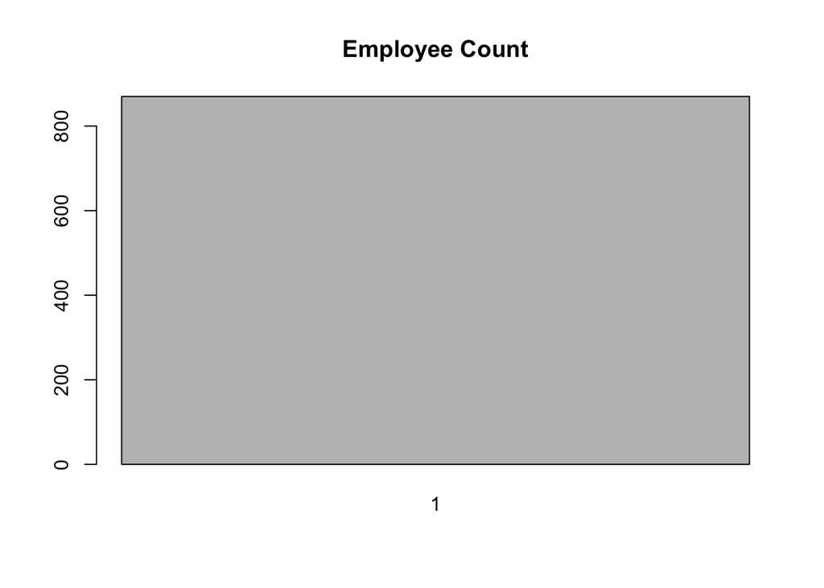

```r
employeecounts <- table(traindata$EmployeeCount)
barplot(employeecounts, main = "Employee Count")
```

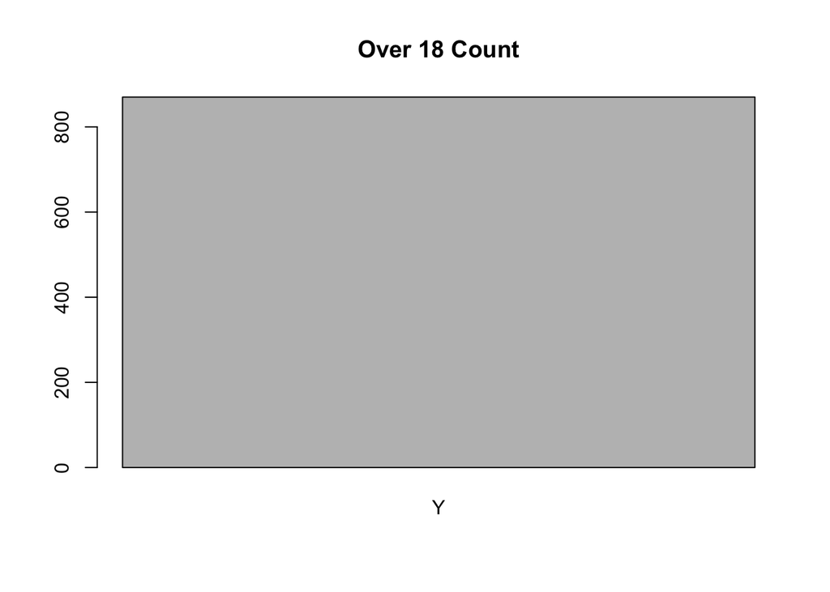

```r
over18 <- table(traindata$Over18)
barplot(over18, main = "Over 18 Count")
```

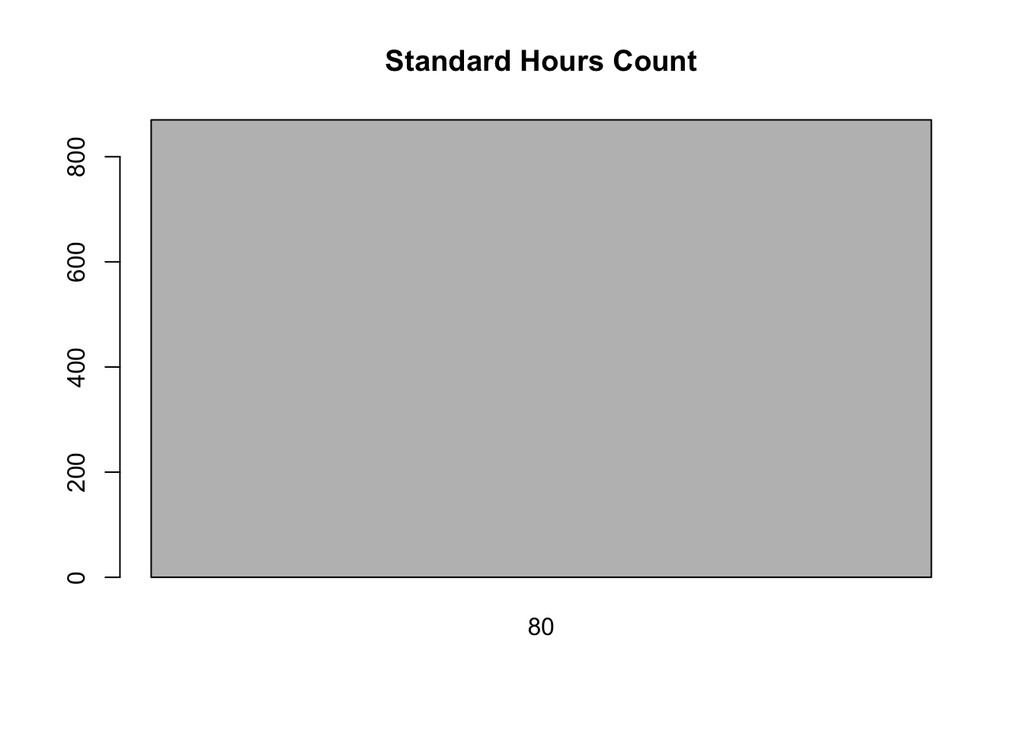

```r
standardhours <- table(traindata$StandardHours)
barplot(standardhours, main = "Standard Hours Count")
```

```r
train <- traindata[,!(names(traindata) %in% c("ID", "StandardHours", "EmployeeNumber", "EmployeeCount", "Over18"))]
```

# EDA

### Run a correlation analysis of variables to see how they relate

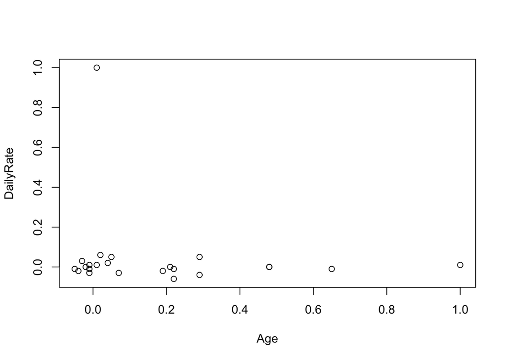

```r
#create a dataframe of numeric values
train_num <-train[, sapply(train, is.numeric)]

# correlation plot
df_corr <- round(cor(train_num), 2)
plot(df_corr)
```

### Count of Attritions, convert attrition to 1,0 instead of Yes or No

```r
counts <- table(traindata$Attrition)
counts
```

```
##
##  No Yes
## 730 140
```

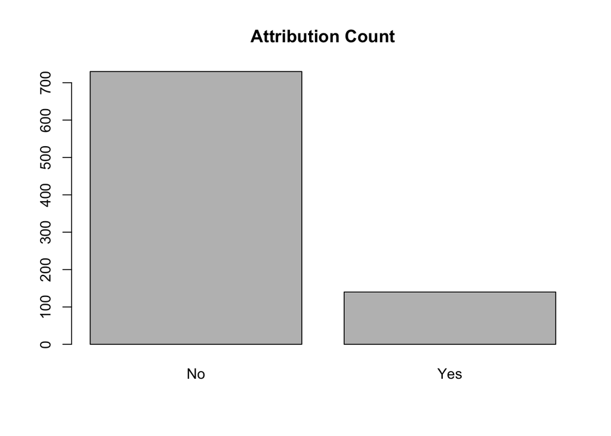

```r
barplot(counts, main = "Attribution Count")
```

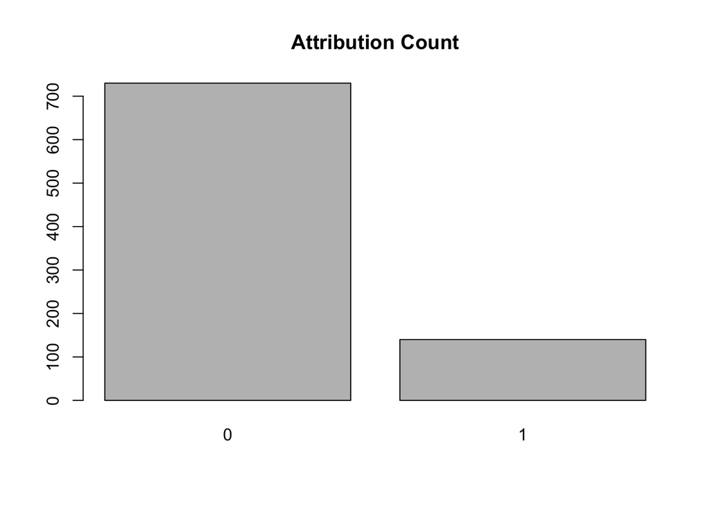

```r
levels(traindata$Attrition) <- c(0,1)
levels(testsalary$Attrition) <- c(0,1)

counts2 <- table(traindata$Attrition)
barplot(counts2, main = "Attribution Count")
```

About 84% of our training data was amongst employees who did not quit and 16% was with those who quit.

### Calculate the means of all our data to see what we can about the total employee base. For fun, let’s also compare the means of people who selected “Yes” for Attrition and those who selected “No”

```r
quitters <- traindata %>% filter(traindata$Attrition == 1)
nonquitters <- traindata %>% filter(traindata$Attrition == 0)
meanquit <- lapply(quitters, mean)
meannonquit <- lapply(nonquitters, mean)
```

A Couple of key notes to flag:

Age - Yes = 33.8 - No = 37.4

Monthly Income - Yes = $4,762 - No = $6,702

Job Satisfaction - Yes = 2.435714 - No = 2.761644

Years with Current Manager - Yes = 2.942857 - No = 4.369863

Job Level - Yes = 1.635714 - No = 2.116438

We can see some early trends emerging with Attrition and how some job qualities may have a significant effect on whether an employee will quit.

### Create age groups to use for our training set

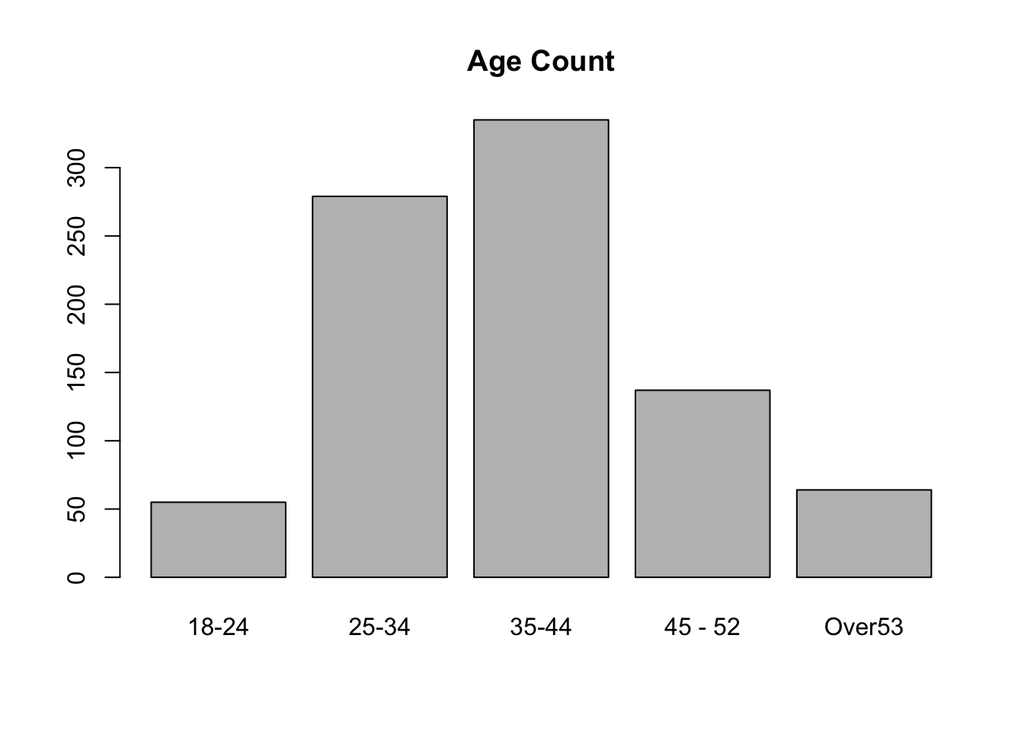

```r
#train$agegroup <- cut(train$Age, breaks = seq(5, 35, 45))
#testattrition$agegroup <- cut(testattrition$Age, breaks = seq(5, 35, 45))
#testsalary$agegroup <- cut(testsalary$Age, breaks = seq(5, 35, 45))

train$agegroup <- with(train, ifelse(Age < 25, "18-24", ifelse(Age < 34, "25-34", ifelse(Age < 44, "35-44", ifelse(Age < 52, "45 - 52", "Over53")))))

testattrition$agegroup <- with(testattrition, ifelse(Age < 25, "18-24", ifelse(Age < 34, "25-34", ifelse(Age < 44, "35-44", ifelse(Age < 52, "45 - 52", "Over53")))))

testsalary$agegroup <- with(testsalary, ifelse(Age < 25, "18-24", ifelse(Age < 34, "25-34", ifelse(Age < 44, "35-44", ifelse(Age < 52, "45 - 52", "Over53")))))

counts3 <- table(train$agegroup)
barplot(counts3, main = "Age Count")
```

After binning up our age groups into a set of 5, we can see that the majority of the employee base is between the ages of 26 and 43. Grouping by age will allow us to better predict the performance of ages indicating attrition and salary.

### Mean Salary for Job Title/ Education and Salary

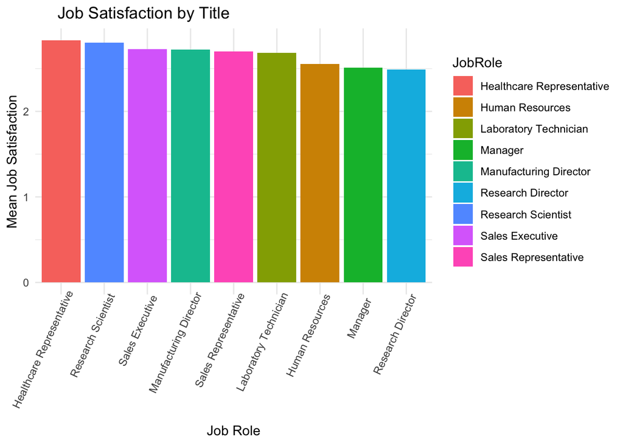

```r
Meansbyjobtitle <- train %>% group_by(JobRole) %>% dplyr::summarise(MedSalary = median(MonthlyIncome, na.rm=TRUE),Meansatis= mean(JobSatisfaction, na.rm=TRUE))


#Subsetting the job satisfaction data into top/bottoms
meanjs <- Meansbyjobtitle %>% arrange(desc(Meansatis))

#Subsetting the salary data into top/bottoms
medsal <- Meansbyjobtitle %>% arrange(desc(MedSalary))

#Mean Job Satisfaction by Job Role
ggplot(meanjs, aes(x=reorder(JobRole,-Meansatis),y=Meansatis,fill=JobRole)) + geom_bar(stat = "identity") + theme_minimal() + theme(plot.title = element_text(hjust=0.1), axis.text.x = element_text(hjust = 0.9, angle = 65)) + labs(x="Job Role", y="Mean Job Satisfaction", title = "Job Satisfaction by Title")
```

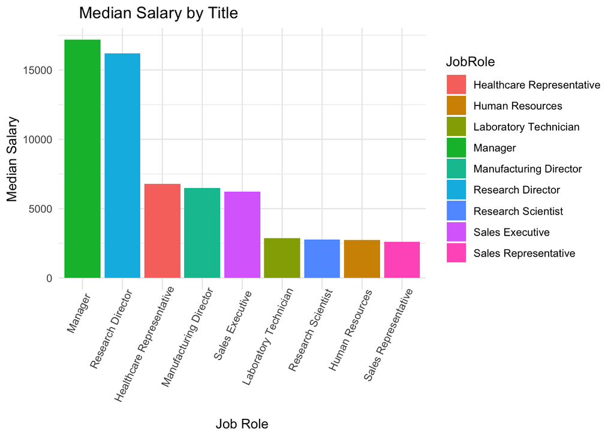

```r
#Median Income by Job Role
ggplot(medsal, aes(x=reorder(JobRole,-MedSalary),y=MedSalary,fill=JobRole)) + geom_bar(stat = "identity") + theme_minimal() + theme(plot.title = element_text(hjust=0.1), axis.text.x = element_text(hjust = 0.9, angle = 65)) + labs(x="Job Role", y="Median Salary", title = "Median Salary by Title")
```

From a mean job salary standpoint, we can see that there is a large gap between the top two paid positions and the other job groups. The Manager level and Research Director positions have the top two salaried levels while the Sales Representatives and Human Resources positions have the lowest two salaries.

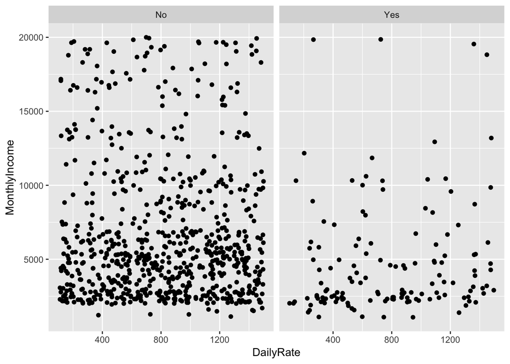

```r
Attritionplot <- ggplot(train, aes(x=DailyRate, y=MonthlyIncome), title ='Attrition') + geom_point()
Attritionplot + facet_wrap(~Attrition)
```

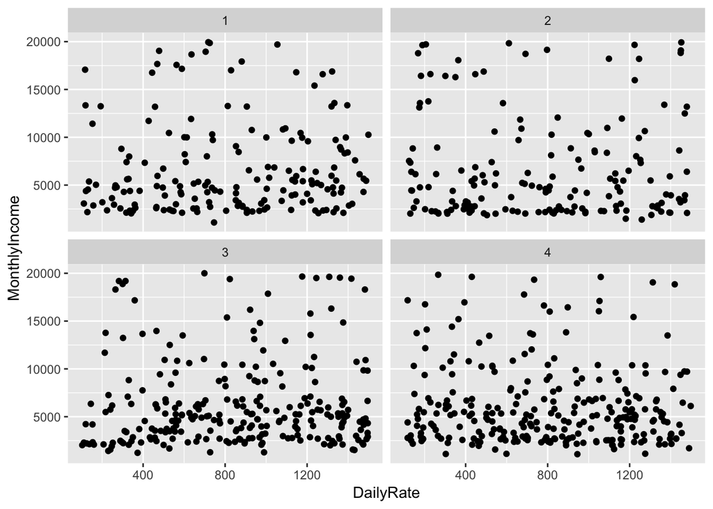

```r
Satisfactionplot <- ggplot(train, aes(x=DailyRate, y=MonthlyIncome), title ='Attrition') + geom_point()
Attritionplot + facet_wrap(~JobSatisfaction)
```

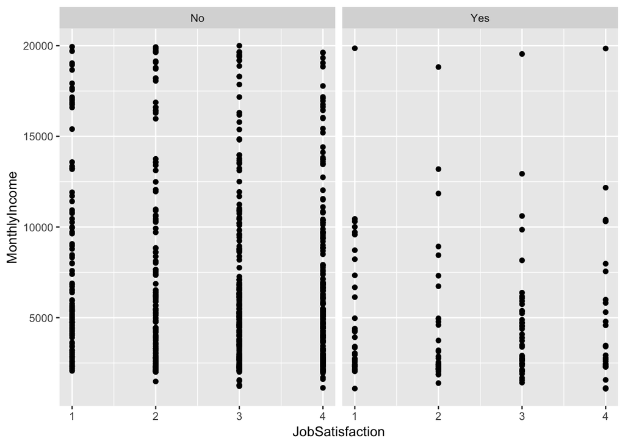

```r
Attritionsat <- ggplot(train, aes(x=JobSatisfaction, y=MonthlyIncome), title ='Attrition') + geom_point()
Attritionsat + facet_wrap(~Attrition)
```

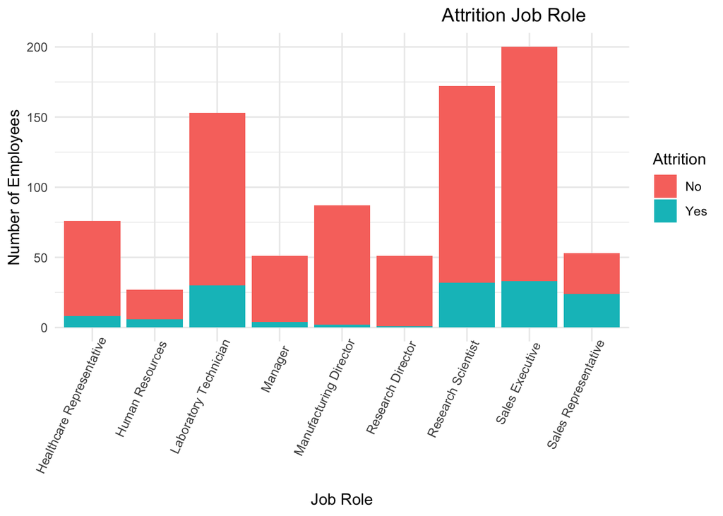

```r
ggplot(train, aes(x=JobRole, fill=Attrition)) + geom_bar() + theme_minimal() + theme(plot.title = element_text(hjust = 0.9), axis.text.x = element_text(hjust=0.9, angle = 65)) + labs(x = "Job Role", y = "Number of Employees", title = "Attrition Job Role")
```

Looking at the relationship between Daily Rate and Monthly income, we can see that there doesn’t appear to be a linear relationship between daily rate and monthly income in both those who quit and those who didn’t.

In Addition, it wasn’t apparent that we are able to see a relationship between job satisfaction and income/rate. Just that more people had a job satisfaction of at least 3 than 2 or less.

Looking triangularly at job satisfaction, income and attrition, we can see that there seems to be a relationship between income and attrition, but not related to job satisfaction. It appears that the lower-income employees are more likely to quit a job than those making a higher salary.

Building an Attribution Plot by job title, we can see there is an alarming turnover rate for Sales Reps at the company with almost 50%, on the other side of the coin, Manufacturing Director and Research director tended to have the lowest turnover rates.

### Group Distance From Home

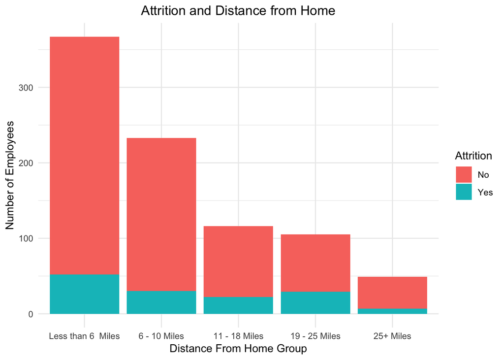

```r
# distance grouping
train$DistanceGrouping <- with(train, ifelse(DistanceFromHome > 25, "25+ Miles", ifelse(DistanceFromHome > 18, "19 - 25 Miles", ifelse(DistanceFromHome > 10, "11 - 18 Miles", ifelse(DistanceFromHome >5, "6 - 10 Miles", "Less than 6  Miles")))))

testattrition$DistanceGrouping <- with(testattrition, ifelse(DistanceFromHome > 25, "25+ Miles", ifelse(DistanceFromHome > 18, "19 - 25 Miles", ifelse(DistanceFromHome > 10, "11 - 18 Miles", ifelse(DistanceFromHome >5, "6 - 10 Miles", "Less than 6  Miles")))))

testsalary$DistanceGrouping <- with(testsalary, ifelse(DistanceFromHome > 25, "25+ Miles", ifelse(DistanceFromHome > 18, "19 - 25 Miles", ifelse(DistanceFromHome > 10, "11 - 18 Miles", ifelse(DistanceFromHome >5, "6 - 10 Miles", "Less than 6  Miles")))))

ggplot(train, aes(x=reorder(DistanceGrouping, DistanceFromHome), fill=Attrition)) + geom_bar() + theme_minimal() + theme(plot.title = element_text(hjust = 0.5)) + labs(x = "Distance From Home Group", y = "Number of Employees", title = "Attrition and Distance from Home")
```

Since commute time may factor in employee’s decision to leave a company, a plot of attrition by distance from home was employed to see if there were any trends available. While there was nothing notable for employees within 18 miles of the office, we did see a noticeable bump in attrition for a smaller pool of employees who live further away.

### Corr Heatmap

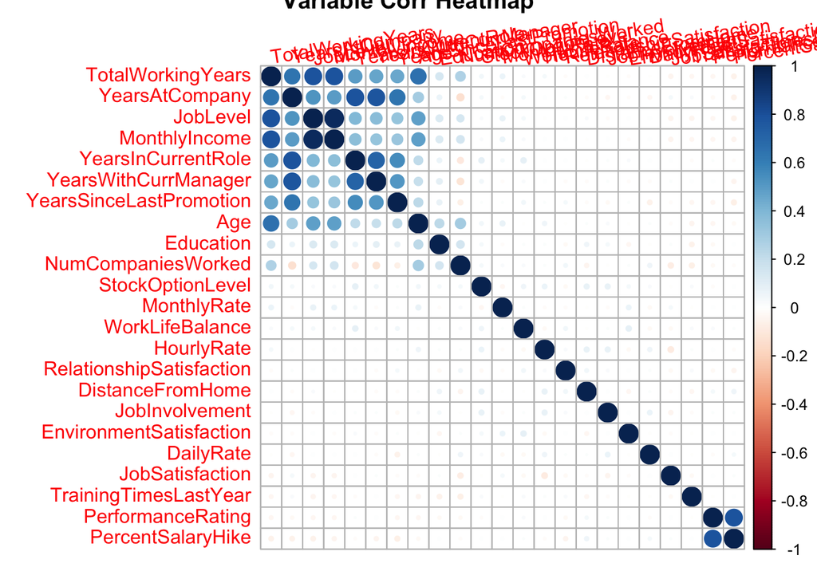

```r
library(corrplot)
corrplot(df_corr, order="FPC", title="Variable Corr Heatmap",tl.srt=9)
```

Reviewing our correlation matrix, we can see instances of high correlation int eh following variables, which would be caused to remove from our models with future analysis.

- Performance Rating and Percent Salary Hike
- Monthly Income and Job Level
- Age and Total Working years
- Years at Current Role and Years at Company
- Years at Company and Years with Current Manager

So with this in mind, we’ll drop the following variables: - Percent Salary Hike - Job Level - Total Working Years - Years at Company ### Removed high correlation variables from set

```r
train2 <- train[,!(names(train) %in% c("YearsAtCompany", "TotalWorkingYears", "JobLevel", "PercentSalaryHike"))]
```

This will be the dataset we use to model our Attrition and Salary Prediction

# Modeling

### Create a train test group

```r
library(caret)
data_part <- createDataPartition(y = train2$Attrition, p = 0.70, list = F)
cvtest <- train2[-data_part,]
cvtrain <- train2[data_part,]

head(cvtrain)
```

```
##   Age Attrition    BusinessTravel DailyRate             Department
## 1  32        No     Travel_Rarely       117                  Sales
## 2  40        No     Travel_Rarely      1308 Research & Development
## 4  32        No     Travel_Rarely       801                  Sales
## 5  24        No Travel_Frequently       567 Research & Development
## 6  27        No Travel_Frequently       294 Research & Development
## 7  41        No     Travel_Rarely      1283 Research & Development
##   DistanceFromHome Education   EducationField EnvironmentSatisfaction
## 1               13         4    Life Sciences                       2
## 2               14         3          Medical                       3
## 4                1         4        Marketing                       3
## 5                2         1 Technical Degree                       1
## 6               10         2    Life Sciences                       4
## 7                5         5          Medical                       2
##   Gender HourlyRate JobInvolvement                JobRole JobSatisfaction
```

[output cut: 34 more lines]

```r
head(cvtest)
```

```
##    Age Attrition    BusinessTravel DailyRate             Department
## 3   35        No Travel_Frequently       200 Research & Development
## 8   37        No     Travel_Rarely       309                  Sales
## 12  28        No        Non-Travel       280        Human Resources
## 14  30        No     Travel_Rarely       202                  Sales
## 15  46        No     Travel_Rarely       991        Human Resources
## 16  31        No        Non-Travel      1188                  Sales
##    DistanceFromHome Education   EducationField EnvironmentSatisfaction
## 3                18         2    Life Sciences                       3
## 8                10         4    Life Sciences                       4
## 12                1         2    Life Sciences                       3
## 14                2         1 Technical Degree                       3
## 15                1         2    Life Sciences                       4
## 16               20         2        Marketing                       4
##    Gender HourlyRate JobInvolvement                JobRole JobSatisfaction
```

[output cut: 41 more lines]

We are going to break up our train2 data into training and testing sets. The training set will help us build a predictive model of attrition and the testing set will be used to evaluate the fit.

## Classification Procedure

```r
lm(Attrition ~., data=cvtrain)
```

```
##
## Call:
## lm(formula = Attrition ~ ., data = cvtrain)
##
## Coefficients:
##                        (Intercept)                                 Age
##                          1.681e+00                          -3.689e-03
##    BusinessTravelTravel_Frequently         BusinessTravelTravel_Rarely
##                          4.841e-02                           2.215e-02
##                          DailyRate    DepartmentResearch & Development
##                         -2.626e-05                           1.823e-01
##                    DepartmentSales                    DistanceFromHome
##                          1.336e-01                          -1.787e-03
##                          Education         EducationFieldLife Sciences
##                         -8.319e-03                          -2.024e-01
##            EducationFieldMarketing               EducationFieldMedical
##                         -1.843e-01                          -1.970e-01
##                EducationFieldOther      EducationFieldTechnical Degree
##                         -1.869e-01                          -1.237e-01
##            EnvironmentSatisfaction                          GenderMale
##                         -3.608e-02                           3.228e-02
##                         HourlyRate                      JobInvolvement
##                          3.440e-04                          -7.515e-02
##             JobRoleHuman Resources        JobRoleLaboratory Technician
##                          2.172e-01                           3.599e-02
##                     JobRoleManager       JobRoleManufacturing Director
##                          3.446e-02                          -7.336e-02
##           JobRoleResearch Director           JobRoleResearch Scientist
##                         -4.388e-02                          -5.556e-03
##             JobRoleSales Executive         JobRoleSales Representative
##                          6.700e-02                           2.546e-01
##                    JobSatisfaction                MaritalStatusMarried
##                         -4.195e-02                           3.206e-02
##                MaritalStatusSingle                       MonthlyIncome
##                          1.347e-01                          -4.316e-06
##                        MonthlyRate                  NumCompaniesWorked
##                         -8.426e-07                           2.200e-02
##                        OverTimeYes                   PerformanceRating
##                          2.314e-01                           5.078e-02
##           RelationshipSatisfaction                    StockOptionLevel
##                         -1.881e-02                          -6.895e-03
##              TrainingTimesLastYear                     WorkLifeBalance
##                         -3.172e-02                          -3.159e-02
##                 YearsInCurrentRole             YearsSinceLastPromotion
##                         -1.154e-02                           1.672e-02
##               YearsWithCurrManager                       agegroup25-34
##                          3.742e-04                           2.744e-02
##                      agegroup35-44                     agegroup45 - 52
##                         -2.451e-02                           1.637e-02
##                     agegroupOver53       DistanceGrouping19 - 25 Miles
##                          7.616e-02                           5.135e-02
##          DistanceGrouping25+ Miles        DistanceGrouping6 - 10 Miles
##                         -7.928e-02                          -7.931e-02
## DistanceGroupingLess than 6  Miles
##                         -8.685e-02
```

From a classification standpoint, we can see that age group, over time, job role and education will play a significant role in the classification of whether an employee will quit or not.

### Naive Bayes Model

```r
library(caret)
library(e1071)
library(MASS)
library(randomForest)
library(naivebayes)
set.seed(12)

Naive_Bayes_train2=naiveBayes(Attrition~., data=cvtrain)

# Predictions
attritionpredict = predict(Naive_Bayes_train2, cvtest)
confusionMatrix(table(attritionpredict, cvtest$Attrition))
```

```
## Confusion Matrix and Statistics
##
##
## attritionpredict  No Yes
##              No  206  22
##              Yes  13  20
##
##                Accuracy : 0.8659
##                  95% CI : (0.8185, 0.9048)
##     No Information Rate : 0.8391
##     P-Value [Acc > NIR] : 0.1358
##
##                   Kappa : 0.4563
##
##  Mcnemar's Test P-Value : 0.1763
##
##             Sensitivity : 0.9406
##             Specificity : 0.4762
##          Pos Pred Value : 0.9035
##          Neg Pred Value : 0.6061
##              Prevalence : 0.8391
##          Detection Rate : 0.7893
##    Detection Prevalence : 0.8736
##       Balanced Accuracy : 0.7084
##
##        'Positive' Class : No
##
```

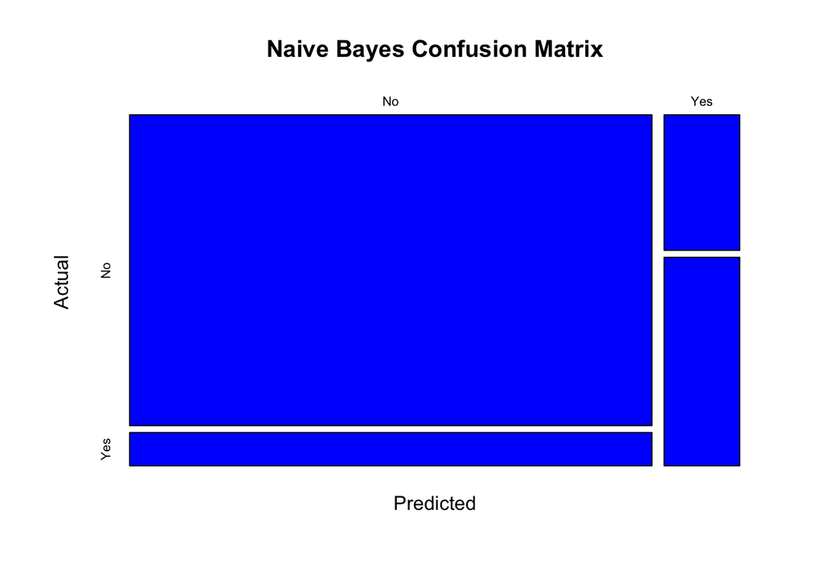

```r
cMatrixNB <- table(attritionpredict, cvtest$Attrition)
plot(cMatrixNB, col="blue", ylab="Actual", xlab="Predicted", main='Naive Bayes Confusion Matrix')
```

### Let’s try a Random Forest Model

```r
library(mboost)
library(kernlab)
library(randomForest)

set.seed(666)

RF_train2 <- train(Attrition ~., cvtrain, method = 'rf', trControl = trainControl(method='repeatedcv'), importance = T)

#RF_train2=randomForest(Attrition~., data=cvtrain, importance = TRUE)
#fit_rf <- randomForest(Attrition ~., data= cvtrain, importance=TRUE)
predTrain <- predict(RF_train2, cvtest)

confusionMatrix(table(cvtest$Attrition, predTrain))
```

```
## Confusion Matrix and Statistics
##
##      predTrain
##        No Yes
##   No  215   4
##   Yes  30  12
##
##                Accuracy : 0.8697
##                  95% CI : (0.8227, 0.9081)
##     No Information Rate : 0.9387
##     P-Value [Acc > NIR] : 1
##
##                   Kappa : 0.3567
##
##  Mcnemar's Test P-Value : 1.807e-05
##
##             Sensitivity : 0.8776
##             Specificity : 0.7500
##          Pos Pred Value : 0.9817
##          Neg Pred Value : 0.2857
##              Prevalence : 0.9387
##          Detection Rate : 0.8238
##    Detection Prevalence : 0.8391
##       Balanced Accuracy : 0.8138
##
##        'Positive' Class : No
##
```

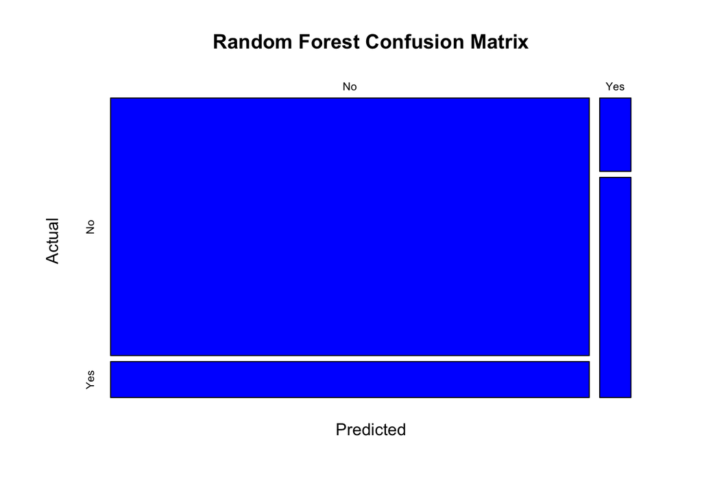

```r
cMatrixRF <- table(predTrain, cvtest$Attrition)
plot(cMatrixRF, col="blue", ylab="Actual", xlab="Predicted", main='Random Forest Confusion Matrix')
```

### Let’s try a Support Vector Machine model

```r
set.seed(777)

svm_train2 <- train(Attrition ~., cvtrain, method = 'svmRadial', trControl = trainControl(method='repeatedcv'), importance=T)

predTrainsvm <- predict(svm_train2, cvtest)

confusionMatrix(table(cvtest$Attrition, predTrainsvm))
```

```
## Confusion Matrix and Statistics
##
##      predTrainsvm
##        No Yes
##   No  219   0
##   Yes  35   7
##
##                Accuracy : 0.8659
##                  95% CI : (0.8185, 0.9048)
##     No Information Rate : 0.9732
##     P-Value [Acc > NIR] : 1
##
##                   Kappa : 0.2513
##
##  Mcnemar's Test P-Value : 9.081e-09
##
##             Sensitivity : 0.8622
##             Specificity : 1.0000
##          Pos Pred Value : 1.0000
##          Neg Pred Value : 0.1667
##              Prevalence : 0.9732
##          Detection Rate : 0.8391
##    Detection Prevalence : 0.8391
##       Balanced Accuracy : 0.9311
##
##        'Positive' Class : No
##
```

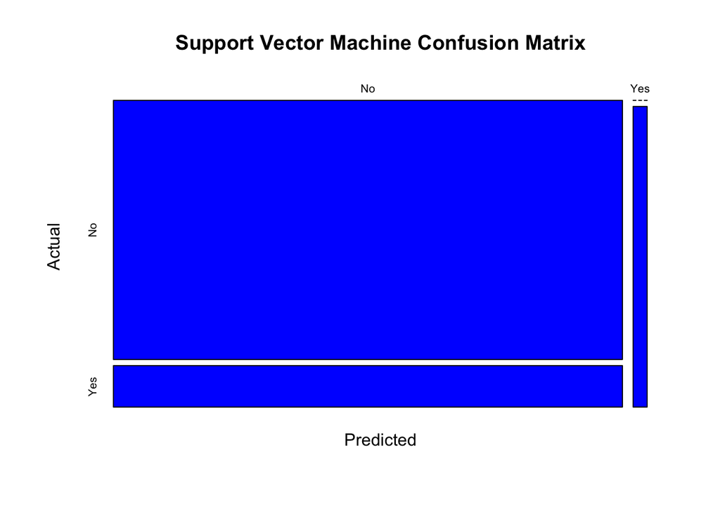

```r
cMatrixsvm <- table(predTrainsvm, cvtest$Attrition)
plot(cMatrixsvm, col="blue", ylab="Actual", xlab="Predicted", main='Support Vector Machine Confusion Matrix')
```

### Feature Importance for Predictive ability

```r
library(rminer)
```

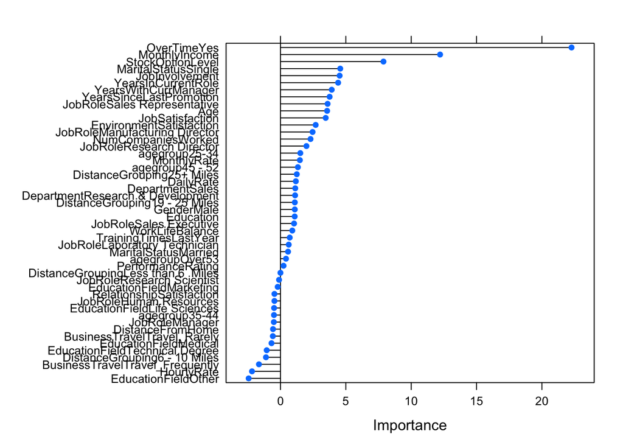

```r
library(mlbench)

rf_import <- varImp(RF_train2, scale = FALSE)
plot(rf_import)
```

```r
#VariableImportance=Importance(svm_train2,cvtrain,method="sensv")

#varImp(svm_train2, scale = FALSE)
#svm_train3 <- as.factor(svm_train2)

#importance(svm_train2)
```

Reviewing the list of variables and their importance on predicting attrition, we can see that the top 3 are as follows:

Overtime_Yes with the vast majority Monthly income Stock Option level

- The overtime piece is interesting as it appears that people who are overworked may be wanting to leave the company. Also, people who are getting overtime pay may be more likely to keep their job and make more.
- Monthly income can also play a factor as people may not want to leave a great salary of those who are making a lower salary may want to quit.
- Stock Options Level typically increases at a company the longer you stay, so we can see how that would correlate with those who quit.

As for this, I will say our random forest model was the best performer at predicting attrition.

## Conclusion

From the implications to the research question standpoint, if Frito lay wants to reduce attrition of quality employees, they would want to re-evaluate their Overtime policy, income level, and stock options level to ensure their good employees are happy within those areas. You can also use this as an ongoing predictive model so that if an employee starts to meet the criteria on these variables that are indicative of attrition, employees could be flagged for a raise or increase in stock options level.

# Salary Prediction

## Check for Collinnearity Within our Salary data

```r
library(HH)
salaryfitincome <- lm(MonthlyIncome ~ ., data = train2)
summary(salaryfitincome)
```

```
##
## Call:
## lm(formula = MonthlyIncome ~ ., data = train2)
##
## Residuals:
##     Min      1Q  Median      3Q     Max
## -4940.2 -1114.5  -147.0   983.1  7346.8
##
## Coefficients:
##                                      Estimate Std. Error t value Pr(>|t|)
## (Intercept)                         7.056e+03  1.523e+03   4.634 4.16e-06
## Age                                 3.592e+01  2.554e+01   1.406 0.160002
## AttritionYes                       -4.180e+01  2.028e+02  -0.206 0.836716
## BusinessTravelTravel_Frequently     8.027e+02  2.469e+02   3.251 0.001196
## BusinessTravelTravel_Rarely         7.773e+02  2.084e+02   3.731 0.000204
## DailyRate                           3.386e-01  1.591e-01   2.128 0.033600
## DepartmentResearch & Development   -1.608e+03  8.283e+02  -1.942 0.052525
## DepartmentSales                    -2.174e+03  8.493e+02  -2.559 0.010662
## DistanceFromHome                    8.785e+01  4.043e+01   2.173 0.030058
## Education                          -1.080e+02  6.547e+01  -1.650 0.099351
## EducationFieldLife Sciences        -4.006e+01  6.461e+02  -0.062 0.950576
## EducationFieldMarketing             4.957e+01  6.840e+02   0.072 0.942252
## EducationFieldMedical              -1.919e+02  6.482e+02  -0.296 0.767303
## EducationFieldOther                 4.304e+01  6.915e+02   0.062 0.950383
## EducationFieldTechnical Degree     -1.182e+02  6.716e+02  -0.176 0.860300
## EnvironmentSatisfaction             2.033e+01  5.863e+01   0.347 0.728897
## GenderMale                          1.423e+02  1.296e+02   1.098 0.272691
## HourlyRate                         -5.119e+00  3.184e+00  -1.608 0.108237
## JobInvolvement                     -1.502e+02  9.276e+01  -1.619 0.105811
## JobRoleHuman Resources             -5.160e+03  8.750e+02  -5.897 5.42e-09
## JobRoleLaboratory Technician       -3.685e+03  2.676e+02 -13.771  < 2e-16
## JobRoleManager                      8.998e+03  4.521e+02  19.903  < 2e-16
## JobRoleManufacturing Director       9.915e+01  2.947e+02   0.336 0.736582
## JobRoleResearch Director            7.996e+03  3.436e+02  23.272  < 2e-16
## JobRoleResearch Scientist          -3.621e+03  2.607e+02 -13.891  < 2e-16
## JobRoleSales Executive              1.551e+02  6.191e+02   0.251 0.802190
## JobRoleSales Representative        -3.379e+03  6.689e+02  -5.052 5.40e-07
## JobSatisfaction                    -1.114e+01  5.813e+01  -0.192 0.848062
## MaritalStatusMarried               -8.161e+01  1.745e+02  -0.468 0.640088
## MaritalStatusSingle                 1.608e+01  2.371e+02   0.068 0.945957
```

[output cut: 60 more lines]

```
## YearsWithCurrManager
## agegroup25-34
## agegroup35-44
## agegroup45 - 52
## agegroupOver53
## DistanceGrouping19 - 25 Miles
## DistanceGrouping25+ Miles          *
## DistanceGrouping6 - 10 Miles       *
## DistanceGroupingLess than 6  Miles .
## ---
## Signif. codes:  0 '***' 0.001 '**' 0.01 '*' 0.05 '.' 0.1 ' ' 1
##
## Residual standard error: 1835 on 821 degrees of freedom
## Multiple R-squared:  0.8495, Adjusted R-squared:  0.8407
## F-statistic: 96.51 on 48 and 821 DF,  p-value: < 2.2e-16
```

```r
vif(salaryfitincome)
```

```
##                                Age                       AttritionYes
##                          13.413006                           1.433677
##    BusinessTravelTravel_Frequently        BusinessTravelTravel_Rarely
##                           2.339884                           2.307205
##                          DailyRate   DepartmentResearch & Development
##                           1.050787                          40.527936
##                    DepartmentSales                   DistanceFromHome
##                          40.118487                          27.915566
##                          Education        EducationFieldLife Sciences
##                           1.157260                          26.114024
##            EducationFieldMarketing              EducationFieldMedical
##                          12.295115                          23.229377
##                EducationFieldOther     EducationFieldTechnical Degree
##                           6.940789                           9.176700
##            EnvironmentSatisfaction                         GenderMale
##                           1.071940                           1.047407
##                         HourlyRate                     JobInvolvement
##                           1.059295                           1.099161
##             JobRoleHuman Resources       JobRoleLaboratory Technician
##                           5.947001                           2.680276
##                     JobRoleManager      JobRoleManufacturing Director
##                           2.912915                           2.018387
##           JobRoleResearch Director          JobRoleResearch Scientist
##                           1.682749                           2.783509
##             JobRoleSales Executive        JobRoleSales Representative
##                          17.523929                           6.611202
##                    JobSatisfaction               MaritalStatusMarried
##                           1.082847                           1.959020
##                MaritalStatusSingle                        MonthlyRate
##                           3.102428                           1.058623
##                 NumCompaniesWorked                        OverTimeYes
##                           1.255912                           1.152942
##                  PerformanceRating           RelationshipSatisfaction
##                           1.032432                           1.048356
##                   StockOptionLevel              TrainingTimesLastYear
##                           1.866492                           1.067384
##                    WorkLifeBalance                 YearsInCurrentRole
##                           1.057949                           2.407821
##            YearsSinceLastPromotion               YearsWithCurrManager
##                           1.654863                           2.248172
##                      agegroup25-34                      agegroup35-44
##                           6.899802                          14.779747
##                    agegroup45 - 52                     agegroupOver53
##                          17.028582                          14.619151
##      DistanceGrouping19 - 25 Miles          DistanceGrouping25+ Miles
##                           4.353688                           5.096495
##       DistanceGrouping6 - 10 Miles DistanceGroupingLess than 6  Miles
##                           5.863803                          18.291230
```

Looking at the interaction rate of all the variables, we can see that the following variables show to have high collinearity per our model, which we can remove. For the variables where we are seeing high collinearity within categorical variables, we will leave in. This is all validated through our significant p-value of <0.0001.

Below are the variables with high collinearity

- Age/Age Group
- Distance Grouping
- Department

### Let’s remove the collinear variables from our dataset

```r
train3 <- train2[,!(names(train2) %in% c("agegroup", "Department", " DistanceGrouping"))]
head(train3)
```

```
##   Age Attrition    BusinessTravel DailyRate DistanceFromHome Education
## 1  32        No     Travel_Rarely       117               13         4
## 2  40        No     Travel_Rarely      1308               14         3
## 3  35        No Travel_Frequently       200               18         2
## 4  32        No     Travel_Rarely       801                1         4
## 5  24        No Travel_Frequently       567                2         1
## 6  27        No Travel_Frequently       294               10         2
##     EducationField EnvironmentSatisfaction Gender HourlyRate
## 1    Life Sciences                       2   Male         73
## 2          Medical                       3   Male         44
## 3    Life Sciences                       3   Male         60
## 4        Marketing                       3 Female         48
## 5 Technical Degree                       1 Female         32
## 6    Life Sciences                       4   Male         32
##   JobInvolvement                JobRole JobSatisfaction MaritalStatus
```

[output cut: 34 more lines]

### Create Train and Test set for our regression model

```r
data_partreg <- createDataPartition(y = train3$MonthlyIncome, p = 0.70, list = F)
cvtestreg <- train3[-data_partreg,]
cvtrainreg <- train3[data_partreg,]

head(cvtestreg)
```

```
##    Age Attrition    BusinessTravel DailyRate DistanceFromHome Education
## 1   32        No     Travel_Rarely       117               13         4
## 2   40        No     Travel_Rarely      1308               14         3
## 7   41        No     Travel_Rarely      1283                5         5
## 8   37        No     Travel_Rarely       309               10         4
## 10  34        No Travel_Frequently       653               10         4
## 11  43        No     Travel_Rarely       823                6         3
##      EducationField EnvironmentSatisfaction Gender HourlyRate
## 1     Life Sciences                       2   Male         73
## 2           Medical                       3   Male         44
## 7           Medical                       2   Male         90
## 8     Life Sciences                       4 Female         88
## 10 Technical Degree                       4   Male         92
## 11          Medical                       1 Female         81
##    JobInvolvement                   JobRole JobSatisfaction MaritalStatus
```

[output cut: 34 more lines]

```r
head(cvtrainreg)
```

```
##    Age Attrition    BusinessTravel DailyRate DistanceFromHome Education
## 3   35        No Travel_Frequently       200               18         2
## 4   32        No     Travel_Rarely       801                1         4
## 5   24        No Travel_Frequently       567                2         1
## 6   27        No Travel_Frequently       294               10         2
## 9   34        No     Travel_Rarely      1333               10         4
## 13  35        No     Travel_Rarely       950                7         3
##      EducationField EnvironmentSatisfaction Gender HourlyRate
## 3     Life Sciences                       3   Male         60
## 4         Marketing                       3 Female         48
## 5  Technical Degree                       1 Female         32
## 6     Life Sciences                       4   Male         32
## 9     Life Sciences                       3 Female         87
## 13            Other                       3   Male         59
##    JobInvolvement                JobRole JobSatisfaction MaritalStatus
```

[output cut: 34 more lines]

Like before, we broke our larger data set into training and test sets. This will be useful in cross-validating our work.

## Regression Procedure

Methodology

We will be performing three different functions to reduce the number of variables and predict the performance of our regression. These will be as follows.

-K- Nearest Neighbors -Random Forest -Support Vector Method

```r
lm(MonthlyIncome ~., data= cvtrainreg)
```

```
##
## Call:
## lm(formula = MonthlyIncome ~ ., data = cvtrainreg)
##
## Coefficients:
##                        (Intercept)                                 Age
##                          5.008e+03                           5.424e+01
##                       AttritionYes     BusinessTravelTravel_Frequently
##                          9.767e+01                           8.129e+02
##        BusinessTravelTravel_Rarely                           DailyRate
##                          8.122e+02                           6.184e-01
##                   DistanceFromHome                           Education
##                          5.594e+01                          -1.178e+02
##        EducationFieldLife Sciences             EducationFieldMarketing
##                         -1.517e+02                          -4.434e+02
##              EducationFieldMedical                 EducationFieldOther
##                         -4.100e+02                           9.581e+01
##     EducationFieldTechnical Degree             EnvironmentSatisfaction
##                         -1.322e+02                           5.146e+01
##                         GenderMale                          HourlyRate
##                          1.391e+02                          -6.405e+00
##                     JobInvolvement              JobRoleHuman Resources
##                         -7.878e+00                          -3.519e+03
##       JobRoleLaboratory Technician                      JobRoleManager
##                         -3.715e+03                           9.430e+03
##      JobRoleManufacturing Director            JobRoleResearch Director
##                          1.245e+02                           8.050e+03
##          JobRoleResearch Scientist              JobRoleSales Executive
##                         -3.584e+03                          -3.190e+02
##        JobRoleSales Representative                     JobSatisfaction
##                         -3.890e+03                           3.092e+01
##               MaritalStatusMarried                 MaritalStatusSingle
##                         -2.079e+02                          -5.406e+01
##                        MonthlyRate                  NumCompaniesWorked
##                         -1.308e-02                           7.454e+01
##                        OverTimeYes                   PerformanceRating
##                         -2.527e+02                          -4.235e+02
##           RelationshipSatisfaction                    StockOptionLevel
##                         -4.128e+01                          -3.510e+01
##              TrainingTimesLastYear                     WorkLifeBalance
##                          2.531e+01                          -6.500e+01
##                 YearsInCurrentRole             YearsSinceLastPromotion
##                          1.026e+02                           1.118e+02
##               YearsWithCurrManager       DistanceGrouping19 - 25 Miles
##                         -9.985e+00                          -4.171e+02
##          DistanceGrouping25+ Miles        DistanceGrouping6 - 10 Miles
##                         -5.882e+02                           4.398e+02
## DistanceGroupingLess than 6  Miles
##                          5.195e+02
```

Looking at the linear model, we can see that job role coefficients are going to be the biggest predictors of monthly income. followed by business travel and performance rating.

# K Nearest Neighbor

```r
library(doParallel)
numcores <- parallel::detectCores() - 1
cl <- makePSOCKcluster(numcores)
registerDoParallel(cl)

set.seed(123)

traind <- trainControl(method = 'repeatedcv', number = 10, repeats = 3)

knn_fit <- train(MonthlyIncome ~ ., data = cvtrainreg, method = 'knn', trControl = traind, preProcess = c('center', 'scale'), tuneLength = 10)

knn_fit
```

```
## k-Nearest Neighbors
##
## 610 samples
##  26 predictor
##
## Pre-processing: centered (42), scaled (42)
## Resampling: Cross-Validated (10 fold, repeated 3 times)
## Summary of sample sizes: 549, 550, 549, 549, 549, 549, ...
## Resampling results across tuning parameters:
##
##   k   RMSE      Rsquared   MAE
##    5  2314.512  0.7293555  1734.906
##    7  2299.503  0.7401493  1730.252
##    9  2333.480  0.7401269  1753.887
##   11  2347.140  0.7432867  1772.245
##   13  2384.096  0.7452764  1799.401
##   15  2423.460  0.7504243  1831.735
##   17  2456.848  0.7570349  1853.208
##   19  2509.597  0.7593032  1884.359
##   21  2544.607  0.7641024  1904.773
##   23  2584.686  0.7689602  1932.823
##
## RMSE was used to select the optimal model using the smallest value.
## The final value used for the model was k = 7.
```

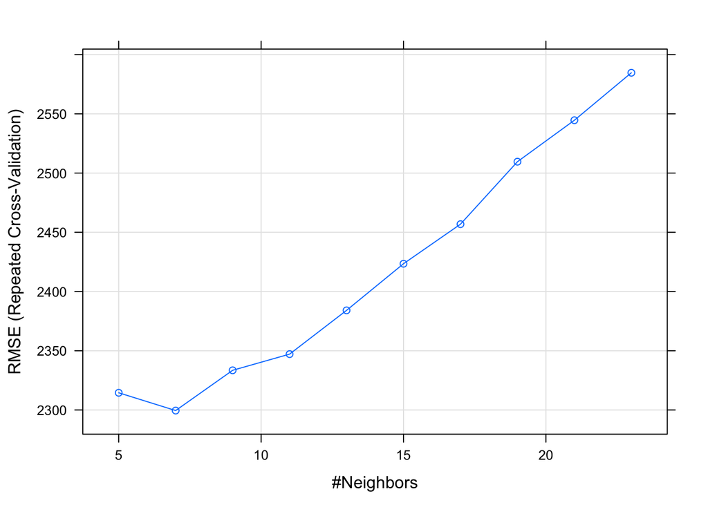

```r
plot(knn_fit)
```

```r
predregtrainknn <- predict(knn_fit, cvtestreg)
```

Our Lowest RMSE came with a K nearest neighbors of 7. This prediction model gives us an RMSE of $2,300 on monthly income, which falls below our $3,000 evaluation criteria.

### Let’ss try with random forest

```r
set.seed(333)
rf_fit <- train(MonthlyIncome ~ ., data = cvtrainreg, method = 'rf', trControl = traind, preProcess = c('center', 'scale'), tuneLength = 10, importance=T)

rf_fit
```

```
## Random Forest
##
## 610 samples
##  26 predictor
##
## Pre-processing: centered (42), scaled (42)
## Resampling: Cross-Validated (10 fold, repeated 3 times)
## Summary of sample sizes: 550, 550, 548, 547, 548, 550, ...
## Resampling results across tuning parameters:
##
##   mtry  RMSE      Rsquared   MAE
##    2    2943.061  0.7356622  2287.801
##    6    2193.549  0.7974851  1721.456
##   10    2004.382  0.8079351  1578.596
##   15    1953.174  0.8070186  1533.138
##   19    1951.660  0.8040598  1528.079
##   24    1970.063  0.7982799  1541.384
##   28    1990.026  0.7938209  1556.428
##   33    2016.985  0.7883700  1576.237
##   37    2036.400  0.7841907  1588.724
##   42    2049.505  0.7814849  1599.212
##
## RMSE was used to select the optimal model using the smallest value.
## The final value used for the model was mtry = 19.
```

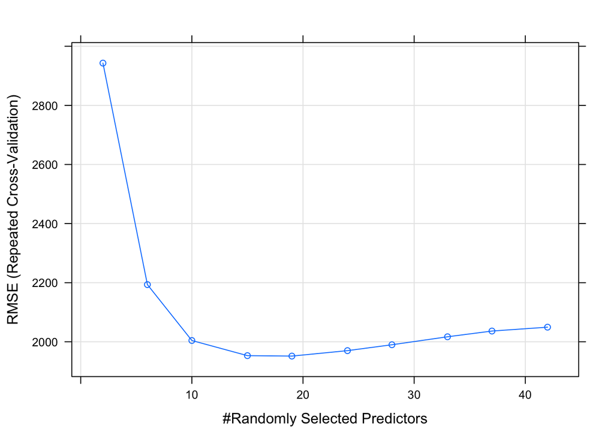

```r
plot(rf_fit)
```

```r
predregtrainrf <- predict(rf_fit, cvtestreg)
```

To compare our KNN procedure, we are going to employ a random forest procedure with our data to predict the Monthly Income of employees.

Like KNN, Random Forest is an ensemble technique capable of performing regression tasks which leverage multiple decision trees, bootstrapped into an aggregate score. Like cross-validation, we are training the training set to validate and make itself smarter.

### Let’s try with the standard variable method

```r
set.seed(333)
svm_fit <- train(MonthlyIncome ~ ., data = cvtrainreg, method = 'svmRadial', trControl = traind, preProcess = c('center', 'scale'), tuneLength = 10, importance=T)

svm_fit
```

```
## Support Vector Machines with Radial Basis Function Kernel
##
## 610 samples
##  26 predictor
##
## Pre-processing: centered (42), scaled (42)
## Resampling: Cross-Validated (10 fold, repeated 3 times)
## Summary of sample sizes: 550, 550, 548, 547, 548, 550, ...
## Resampling results across tuning parameters:
##
##   C       RMSE      Rsquared   MAE
##     0.25  2453.964  0.7772103  1754.834
##     0.50  2139.376  0.7916098  1600.300
##     1.00  2038.465  0.7909608  1561.496
##     2.00  2035.270  0.7855038  1581.352
##     4.00  2084.057  0.7746147  1631.257
##     8.00  2140.430  0.7623760  1674.461
##    16.00  2174.128  0.7553743  1702.683
##    32.00  2178.660  0.7544098  1707.139
##    64.00  2178.660  0.7544098  1707.139
##   128.00  2178.660  0.7544098  1707.139
##
## Tuning parameter 'sigma' was held constant at a value of 0.01307046
## RMSE was used to select the optimal model using the smallest value.
## The final values used for the model were sigma = 0.01307046 and C = 2.
```

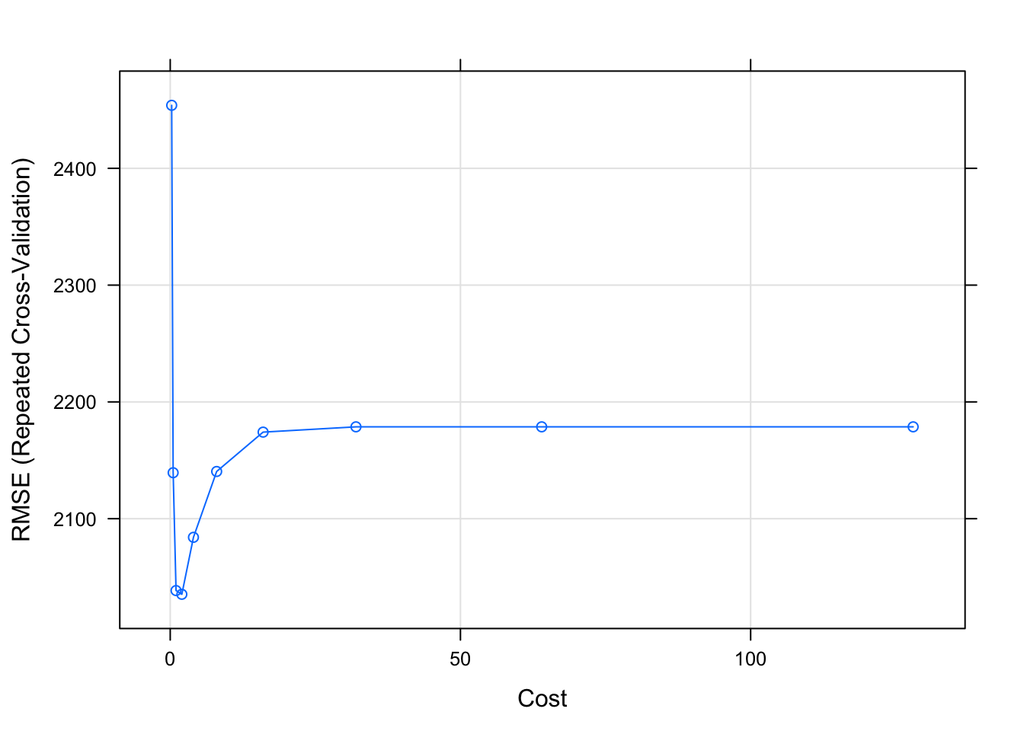

```r
plot(svm_fit)
```

```r
predregtrainsvm <- predict(svm_fit, cvtestreg)
```

In hopes to improve on our random forest score, Support Vector Machines are a subclass of supervised regressors that attempt to regress a feature space into a set of regressive linear predictors.

So with the 3 models in question, we will use the random forest predictor as our final model.

### Variable importance of our regressor

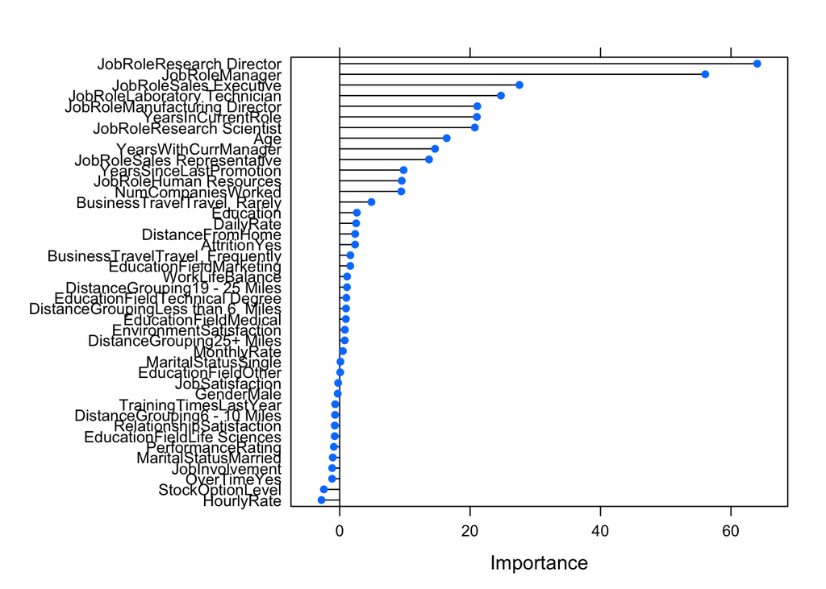

```r
rfimportreg <- varImp(rf_fit, scale = FALSE)
#svmimportreg <- varImp(svm_fit, scale = FALSE)

plot(rfimportreg)
```

```r
#plot(svmimportreg)
```

## Conclusion

From the implications to the research question standpoint, Frito Lay can reduce attrition of quality of employees if they can predict which one will leave and provide them an offer related to Stock Option Value, Overtime, and Monthly Income. This could come in the form of a raise, or a bump in an employee’s vested interest and potentially offering overtime to help keep people happy and working for the company.

This could be powerful as they can plot out their futures and optimize their growth over time.

## Output data

```r
#run prediction on rf classification model using our test set
dftestpreds <- predict(RF_train2, testattrition)

dftestpreds1 <- cbind(testattrition$ID, dftestpreds)
dfclasspred <- as.data.frame(dftestpreds1)
dfclasspred$Attrition <- with(dfclasspred, ifelse(dftestpreds == 1, "No", "Yes"))
classtestfinal <- dfclasspred[,!(names(dfclasspred) %in% c("dftestpreds"))]

#outputting data
write.csv(classtestfinal,"/Users/danielclark/Desktop/SMU/DoingDataScience/Project2/DanielClark_DDSCaseStudy2_PredictAttrition.csv",row.names = FALSE)
```

```r
#run prediction on rf classification model using our test set
testsalary$Attrition <- with(testsalary, ifelse(Attrition == 1, "Yes", "No"))

dftestregress <- predict(rf_fit, testsalary)

dftestpreds2 <- cbind(testsalary$ID, dftestregress)
dfregpred <- as.data.frame(dftestpreds2)
names(dfregpred)<- c("ID", "MonthlySalary")

#outputting data
write.csv(classtestfinal,"/Users/danielclark/Desktop/SMU/DoingDataScience/Project2/DanielClark_DDSCaseStudy2_PredictSalary.csv",row.names = FALSE)
```

GitHub Link - https://github.com/dclark18/CaseStudy2DDS- Youtube Link - https://youtu.be/YTCdQHtOVpw